# Demographic table, linear regression and mediation anlysis with missing data points

Author

R. Gaizauskaite

### Libraries

```r
library(tidyverse)
library(rstatix)
library(gtsummary)
library(lmtest)
library(ggpubr)
library(car)
library(MASS)
library(nortest)
```

## 1. Main analysis

### 1. 1 Demographic table

```r
Demographic_data <- CST_full_parameters |> dplyr::select(Age:Tes,-Sex, -anxiety)

demographic_summary_1 <- Demographic_data |>
  tbl_summary(
    by = Group,
    missing = "no",
    statistic = list(
      all_continuous() ~ "{mean} ({sd})"
    )
  ) |>
  add_p(
    test = all_continuous() ~ "aov",
    pvalue_fun = function(x) style_pvalue(x, digits = 2)
  )

demographic_summary_1
```

| **Characteristic** | **Males**, N = 35<sup>1</sup> | **NCF**, N = 37<sup>1</sup> | **NCL**, N = 36<sup>1</sup> | **OC**, N = 27<sup>1</sup> | **IUD**, N = 31<sup>1</sup> | **p-value**<sup>2</sup> |
| --- | --- | --- | --- | --- | --- | --- |
| Age | 26.5 (4.1) | 27.6 (5.2) | 26.4 (4.4) | 24.1 (3.6) | 27.5 (4.3) | 0.025 |
| STEM |  |  |  |  |  | 0.001 |
| 0 | 11 (31%) | 29 (78%) | 24 (67%) | 14 (52%) | 19 (61%) |  |
| 1 | 24 (69%) | 8 (22%) | 12 (33%) | 13 (48%) | 12 (39%) |  |
| PANAS_PA | 35.5 (4.8) | 38.0 (5.6) | 36.7 (6.2) | 34.8 (5.7) | 36.8 (6.2) | 0.19 |
| PANAS_NA | 23 (7) | 26 (7) | 26 (8) | 24 (7) | 26 (6) | 0.27 |
| EA1 | 2.59 (2.00) | 3.49 (2.35) | 3.22 (2.30) | 3.26 (2.51) | 3.59 (2.34) | 0.43 |
| EA2 | 3.79 (2.44) | 4.86 (2.58) | 5.02 (2.43) | 4.57 (2.66) | 4.83 (2.81) | 0.29 |
| Tiredness_1 | 3.05 (2.16) | 2.91 (2.27) | 2.96 (2.33) | 2.84 (2.40) | 2.94 (2.25) | >0.99 |
| Tiredness_2 | 5.32 (2.33) | 5.01 (2.23) | 6.03 (1.97) | 5.52 (1.79) | 5.57 (2.48) | 0.40 |
| Femininity | 4.37 (0.46) | 5.02 (0.54) | 5.11 (0.42) | 4.81 (0.48) | 4.88 (0.54) | <0.001 |
| Masculinity | 4.79 (0.66) | 4.28 (0.64) | 4.39 (0.66) | 4.25 (0.75) | 4.10 (0.80) | 0.001 |
| P4 | NA (NA) | 74 (48) | 209 (128) | 103 (63) | 100 (85) | <0.001 |
| E2 | NA (NA) | 1.37 (0.49) | 1.48 (0.54) | 1.26 (0.82) | 1.48 (0.63) | 0.44 |
| Tes | 234 (65) | 76 (26) | 78 (24) | 57 (17) | 81 (27) | <0.001 |

<sup>1</sup> Mean (SD); n (%)  
<sup>2</sup> One-way ANOVA; Pearson’s Chi-squared test

### 1.3. Linear regression model

### 1.3.1 Women

```r
women_data <- women_data |> drop_na( EA1, EA2, Tiredness_1, Tiredness_2, P4, E2, Tes)
```

#### Running first LM model with all the variables

```r
women_lm_model <- lm(accu~ OC + IUD + NCL + Age + STEM + PANAS_PA + PANAS_NA + EA1 + EA2 + Tiredness_1 + Tiredness_2 + Femininity + Masculinity + P4 + E2 +Tes, data = women_data)
```

```r
summary(women_lm_model)
```

```
Call:
lm(formula = accu ~ OC + IUD + NCL + Age + STEM + PANAS_PA +
    PANAS_NA + EA1 + EA2 + Tiredness_1 + Tiredness_2 + Femininity +
    Masculinity + P4 + E2 + Tes, data = women_data)

Residuals:
    Min      1Q  Median      3Q     Max
-44.263  -9.525   0.995  11.679  30.669

Coefficients:
              Estimate Std. Error t value Pr(>|t|)
(Intercept) 111.703975  24.362487   4.585  1.3e-05 ***
OC1          -3.193958   5.239457  -0.610 0.543498
IUD1          6.178107   4.539917   1.361 0.176593
NCL1         -2.799897   5.231012  -0.535 0.593654
Age          -0.291809   0.429910  -0.679 0.498837
STEM1         3.947563   3.968007   0.995 0.322188
PANAS_PA     -0.057468   0.344990  -0.167 0.868035
PANAS_NA     -0.132111   0.252476  -0.523 0.601939
EA1           0.106711   0.789616   0.135 0.892768
EA2          -2.782723   0.702995  -3.958 0.000141 ***
Tiredness_1  -0.171982   0.784319  -0.219 0.826878
Tiredness_2  -0.230315   0.860157  -0.268 0.789430
Femininity   -4.533461   3.823147  -1.186 0.238486
Masculinity   3.342475   2.624539   1.274 0.205747
P4            0.004002   0.019948   0.201 0.841403
E2            0.492229   3.013228   0.163 0.870565
Tes          -0.109107   0.073303  -1.488 0.139750
---
Signif. codes:  0 '***' 0.001 '**' 0.01 '*' 0.05 '.' 0.1 ' ' 1

Residual standard error: 17.03 on 101 degrees of freedom
  (1 observation deleted due to missingness)
Multiple R-squared:  0.2441,    Adjusted R-squared:  0.1244
F-statistic: 2.039 on 16 and 101 DF,  p-value: 0.01723
```

#### Multicolinearity check up

```r
vif(women_lm_model)
```

```
         OC         IUD         NCL         Age        STEM    PANAS_PA
   1.808736    1.553629    2.241650    1.597759    1.434706    1.642629
   PANAS_NA         EA1         EA2 Tiredness_1 Tiredness_2  Femininity
   1.266090    1.434451    1.333474    1.294522    1.433901    1.513498
Masculinity          P4          E2         Tes
   1.332219    1.766198    1.327390    1.335273
```

All VIF score < 3, no multicolinearity

#### AIC procedure

```r
stepAIC(women_lm_model, direction = "backward")
```

```
Start:  AIC=684.76
accu ~ OC + IUD + NCL + Age + STEM + PANAS_PA + PANAS_NA + EA1 +
    EA2 + Tiredness_1 + Tiredness_2 + Femininity + Masculinity +
    P4 + E2 + Tes

              Df Sum of Sq   RSS    AIC
- EA1          1       5.3 29313 682.78
- E2           1       7.7 29315 682.79
- PANAS_PA     1       8.1 29315 682.79
- P4           1      11.7 29319 682.81
- Tiredness_1  1      14.0 29321 682.82
- Tiredness_2  1      20.8 29328 682.84
- PANAS_NA     1      79.4 29387 683.08
- NCL          1      83.1 29390 683.09
- OC           1     107.8 29415 683.19
- Age          1     133.7 29441 683.30
- STEM         1     287.2 29594 683.91
- Femininity   1     408.0 29715 684.39
- Masculinity  1     470.6 29778 684.64
<none>                     29307 684.76
- IUD          1     537.4 29845 684.90
- Tes          1     642.9 29950 685.32
- EA2          1    4546.6 33854 699.78

Step:  AIC=682.78
accu ~ OC + IUD + NCL + Age + STEM + PANAS_PA + PANAS_NA + EA2 +
    Tiredness_1 + Tiredness_2 + Femininity + Masculinity + P4 +
    E2 + Tes

              Df Sum of Sq   RSS    AIC
- E2           1       6.1 29319 680.80
- PANAS_PA     1       6.4 29319 680.81
- Tiredness_1  1      10.5 29323 680.82
- P4           1      11.3 29324 680.83
- Tiredness_2  1      22.5 29335 680.87
- PANAS_NA     1      76.6 29389 681.09
- NCL          1      81.5 29394 681.11
- OC           1     103.6 29416 681.20
- Age          1     131.0 29444 681.31
- STEM         1     312.5 29625 682.03
```

[output cut: 143 more lines]

```
- Femininity   1     622.9 30261 668.54
- IUD          1    1158.7 30797 670.61
- EA2          1    5715.8 35354 686.89

Step:  AIC=666.65
accu ~ IUD + STEM + EA2 + Femininity + Masculinity + Tes

              Df Sum of Sq   RSS    AIC
<none>                     29780 666.65
- Masculinity  1     521.8 30302 666.70
- STEM         1     525.6 30306 666.71
- Femininity   1     556.9 30337 666.84
- Tes          1     585.0 30365 666.94
- IUD          1    1053.8 30834 668.75
- EA2          1    5911.3 35692 686.01
```

```
Call:
lm(formula = accu ~ IUD + STEM + EA2 + Femininity + Masculinity +
    Tes, data = women_data)

Coefficients:
(Intercept)         IUD1        STEM1          EA2   Femininity  Masculinity
   95.62381      7.17152      4.78465     -2.81476     -4.54077      3.32259
        Tes
   -0.09603
```

As model suggest IUD group to stay, i would do little bit differently and IUD group leave as reference group to account for all hormonal status groups.

#### Final model

```r
women_final <- lm(accu ~ OC + NCF + NCL + + STEM + EA2 + Femininity + Masculinity + Tes, data  = women_data)
```

```r
summary(women_final)
```

```
Call:
lm(formula = accu ~ OC + NCF + NCL + +STEM + EA2 + Femininity +
    Masculinity + Tes, data = women_data)

Residuals:
    Min      1Q  Median      3Q     Max
-44.867  -9.743   1.019  11.413  32.589

Coefficients:
             Estimate Std. Error t value Pr(>|t|)
(Intercept) 102.54345   17.77767   5.768 7.60e-08 ***
OC1          -7.60185    4.83111  -1.574   0.1185
NCF1         -5.90623    4.34805  -1.358   0.1772
NCL1         -8.06681    4.32191  -1.866   0.0647 .
STEM1         5.00792    3.47911   1.439   0.1529
EA2          -2.81088    0.60698  -4.631 1.01e-05 ***
Femininity   -4.51268    3.24613  -1.390   0.1673
Masculinity   3.32753    2.40535   1.383   0.1694
Tes          -0.09615    0.06796  -1.415   0.1600
---
Signif. codes:  0 '***' 0.001 '**' 0.01 '*' 0.05 '.' 0.1 ' ' 1

Residual standard error: 16.51 on 109 degrees of freedom
  (1 observation deleted due to missingness)
Multiple R-squared:  0.234, Adjusted R-squared:  0.1778
F-statistic: 4.162 on 8 and 109 DF,  p-value: 0.0002265
```

#### Assumption testing

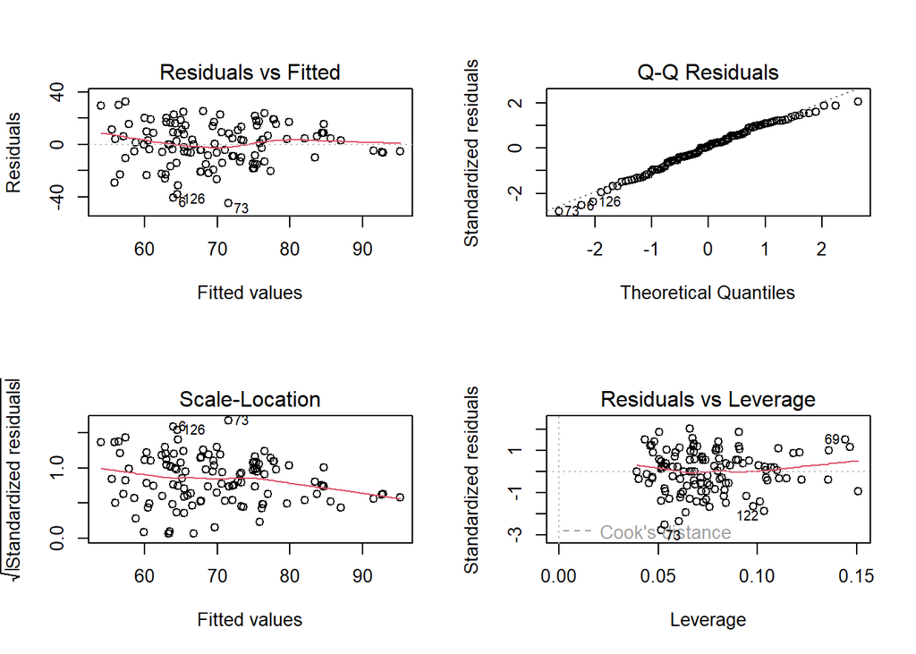

**Homoscedasticity test**

```r
bptest(women_final)
```

```
    studentized Breusch-Pagan test

data:  women_final
BP = 8.3721, df = 8, p-value = 0.398
```

Homoscedacity assumption is not violated, p > 0.05

**Independence of Errors test:**

```r
durbinWatsonTest(women_final)
```

```
 lag Autocorrelation D-W Statistic p-value
   1    -0.002973407      2.005078   0.808
 Alternative hypothesis: rho != 0
```

**Conclusion:** The model show good fit.

#### Polinomynal regression analysis for testosterone

```r
quadratic_model_women <- lm(accu  ~ poly(Tes, 2, raw = TRUE), data = women_data)
summary(quadratic_model_women)
```

```
Call:
lm(formula = accu ~ poly(Tes, 2, raw = TRUE), data = women_data)

Residuals:
    Min      1Q  Median      3Q     Max
-46.471  -9.614  -0.703  14.593  31.435

Coefficients:
                           Estimate Std. Error t value Pr(>|t|)
(Intercept)               79.639093  12.789421   6.227 8.01e-09 ***
poly(Tes, 2, raw = TRUE)1 -0.221376   0.328481  -0.674    0.502
poly(Tes, 2, raw = TRUE)2  0.001065   0.001991   0.535    0.594
---
Signif. codes:  0 '***' 0.001 '**' 0.01 '*' 0.05 '.' 0.1 ' ' 1

Residual standard error: 18.3 on 115 degrees of freedom
  (1 observation deleted due to missingness)
Multiple R-squared:  0.007017,  Adjusted R-squared:  -0.01025
F-statistic: 0.4064 on 2 and 115 DF,  p-value: 0.667
```

No quadratic effect of testosterone.

### 1.3.2. Men

**Tidying the table**

#### Running first LM model with all the variables

```r
men_lm_model <- lm(accu~ Age + STEM + PANAS_PA + PANAS_NA + EA1 + EA2 + Tiredness_1 + Tiredness_2 + Femininity + Masculinity +Tes, data = men_data)
```

```r
summary(men_lm_model)
```

```
Call:
lm(formula = accu ~ Age + STEM + PANAS_PA + PANAS_NA + EA1 +
    EA2 + Tiredness_1 + Tiredness_2 + Femininity + Masculinity +
    Tes, data = men_data)

Residuals:
    Min      1Q  Median      3Q     Max
-35.598  -8.410   2.911   8.555  17.355

Coefficients:
            Estimate Std. Error t value Pr(>|t|)
(Intercept) 97.01366   56.86318   1.706   0.1021
Age         -0.10442    0.79506  -0.131   0.8967
STEM1        5.64451    7.00899   0.805   0.4293
PANAS_PA    -0.85957    0.99851  -0.861   0.3986
PANAS_NA    -0.25028    0.54523  -0.459   0.6507
EA1          3.78440    1.77406   2.133   0.0443 *
EA2         -1.42315    1.45203  -0.980   0.3377
Tiredness_1 -2.75444    1.77045  -1.556   0.1340
Tiredness_2  0.63243    1.58703   0.399   0.6941
Femininity   1.25266    9.18250   0.136   0.8927
Masculinity  7.14895    5.75090   1.243   0.2269
Tes         -0.07301    0.05407  -1.350   0.1907
---
Signif. codes:  0 '***' 0.001 '**' 0.01 '*' 0.05 '.' 0.1 ' ' 1

Residual standard error: 15.97 on 22 degrees of freedom
Multiple R-squared:  0.3462,    Adjusted R-squared:  0.01929
F-statistic: 1.059 on 11 and 22 DF,  p-value: 0.4337
```

#### AIC procedure

```r
stepAIC(men_lm_model, direction = "backward")
```

```
Start:  AIC=197.59
accu ~ Age + STEM + PANAS_PA + PANAS_NA + EA1 + EA2 + Tiredness_1 +
    Tiredness_2 + Femininity + Masculinity + Tes

              Df Sum of Sq    RSS    AIC
- Age          1      4.40 5612.6 195.62
- Femininity   1      4.74 5612.9 195.62
- Tiredness_2  1     40.48 5648.7 195.84
- PANAS_NA     1     53.71 5661.9 195.91
- STEM         1    165.33 5773.5 196.58
- PANAS_PA     1    188.91 5797.1 196.72
- EA2          1    244.88 5853.1 197.04
<none>                     5608.2 197.59
- Masculinity  1    393.92 6002.1 197.90
- Tes          1    464.78 6073.0 198.30
- Tiredness_1  1    617.02 6225.2 199.14
- EA1          1   1159.99 6768.2 201.98

Step:  AIC=195.62
accu ~ STEM + PANAS_PA + PANAS_NA + EA1 + EA2 + Tiredness_1 +
    Tiredness_2 + Femininity + Masculinity + Tes

              Df Sum of Sq    RSS    AIC
- Femininity   1      3.91 5616.5 193.64
- Tiredness_2  1     38.49 5651.1 193.85
- PANAS_NA     1     49.98 5662.6 193.92
- STEM         1    164.53 5777.1 194.60
- PANAS_PA     1    186.42 5799.0 194.73
- EA2          1    245.56 5858.1 195.07
<none>                     5612.6 195.62
- Masculinity  1    392.23 6004.8 195.91
- Tes          1    464.15 6076.7 196.32
- Tiredness_1  1    653.77 6266.4 197.36
- EA1          1   1167.59 6780.2 200.04

Step:  AIC=193.64
accu ~ STEM + PANAS_PA + PANAS_NA + EA1 + EA2 + Tiredness_1 +
    Tiredness_2 + Masculinity + Tes

              Df Sum of Sq    RSS    AIC
```

[output cut: 81 more lines]

```

Step:  AIC=186.63
accu ~ EA1 + Tes

       Df Sum of Sq    RSS    AIC
- Tes   1    340.22 7238.3 186.27
<none>              6898.0 186.63
- EA1   1   1430.79 8328.8 191.04

Step:  AIC=186.27
accu ~ EA1

       Df Sum of Sq    RSS    AIC
<none>              7238.3 186.27
- EA1   1    1339.5 8577.8 190.04
```

```
Call:
lm(formula = accu ~ EA1, data = men_data)

Coefficients:
(Intercept)          EA1
     75.095        3.179
```

#### Final model

```r
men_final <- lm(accu ~ EA1, data = men_data)
```

```r
summary(men_final)
```

```
Call:
lm(formula = accu ~ EA1, data = men_data)

Residuals:
    Min      1Q  Median      3Q     Max
-36.213  -8.279   3.146  10.169  21.725

Coefficients:
            Estimate Std. Error t value Pr(>|t|)
(Intercept)   75.095      4.256  17.645   <2e-16 ***
EA1            3.179      1.306   2.433   0.0207 *
---
Signif. codes:  0 '***' 0.001 '**' 0.01 '*' 0.05 '.' 0.1 ' ' 1

Residual standard error: 15.04 on 32 degrees of freedom
Multiple R-squared:  0.1562,    Adjusted R-squared:  0.1298
F-statistic: 5.922 on 1 and 32 DF,  p-value: 0.02072
```

#### Assumptions testing

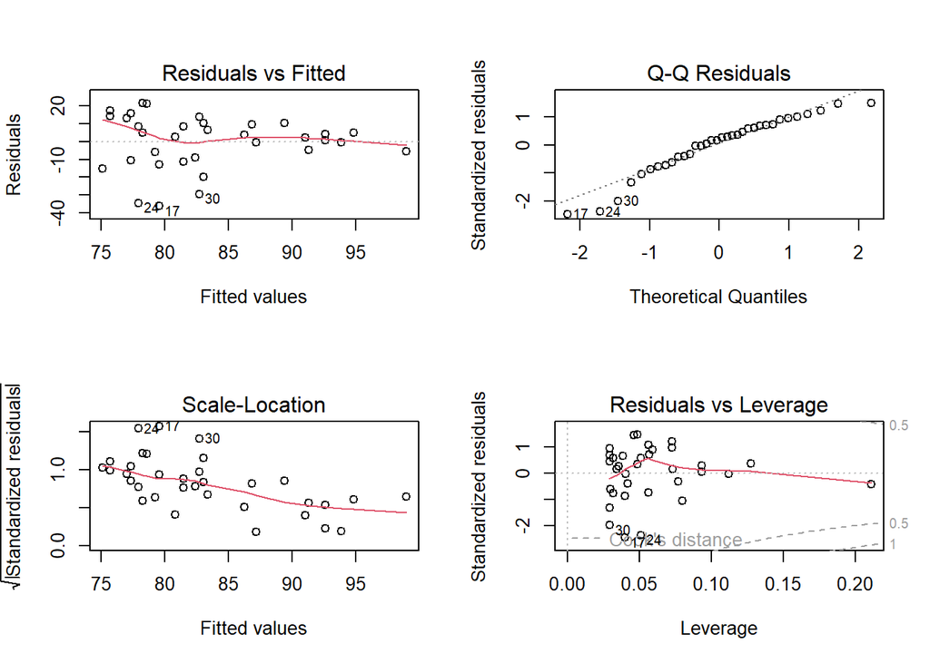

**Normality of residuals**

```r
ad.test(model.metrics.men$.resid)
```

```
    Anderson-Darling normality test

data:  model.metrics.men$.resid
A = 0.6513, p-value = 0.08163
```

IN QQ plot we can see that there is three outliers, otherwise the plot looks normal. At larger sample sizes the Shapiro-Wilk test becomes very sensitive even to a minor deviation from normality. Anderson-Darling normality test p > 0.05, therefore I assume normal distribution.

**Homoscedasticity test**

```r
bptest(men_final)
```

```
    studentized Breusch-Pagan test

data:  men_final
BP = 4.8322, df = 1, p-value = 0.02793
```

Probably 17, 24, 30 are “outliers” which are effecting homoscedacity. Homoscedacity assuption is violated

**Independence of Errors test:**

```r
durbinWatsonTest(men_final)
```

```
 lag Autocorrelation D-W Statistic p-value
   1       -0.290821       2.57023   0.076
 Alternative hypothesis: rho != 0
```

The independence of error assumption is notviolated.

**Conclusion:** Some assumptions are violated therefore the model should be interpreted with cautious.

#### Polinomynal regression analysis for testosterone

```r
quadratic_model_men <- lm(accu ~ poly(Tes, 2, raw = TRUE), data = men_data)
```

```r
summary(quadratic_model_men)
```

```
Call:
lm(formula = accu ~ poly(Tes, 2, raw = TRUE), data = men_data)

Residuals:
    Min      1Q  Median      3Q     Max
-40.963  -9.855   5.605  12.108  19.393

Coefficients:
                            Estimate Std. Error t value Pr(>|t|)
(Intercept)                1.139e+02  2.825e+01   4.031 0.000335 ***
poly(Tes, 2, raw = TRUE)1 -2.345e-01  2.475e-01  -0.947 0.350728
poly(Tes, 2, raw = TRUE)2  4.131e-04  5.223e-04   0.791 0.434995
---
Signif. codes:  0 '***' 0.001 '**' 0.01 '*' 0.05 '.' 0.1 ' ' 1

Residual standard error: 16.23 on 31 degrees of freedom
Multiple R-squared:  0.04823,   Adjusted R-squared:  -0.01318
F-statistic: 0.7854 on 2 and 31 DF,  p-value: 0.4648
```

No quadratic effect of testosterone

### 1.4 Mediation analysis

*Output of mediation analysis is not accessible as PROCESS v4.3 functions available as script, not a R package.*

```r
CST_full_parameters <- CST_full_parameters |>
                          mutate(Group = as.numeric(Group),
                                STEM = as.numeric(STEM),
                                Sex =  as.numeric(Sex))
```

```r
process (data = CST_full_parameters, y = "accu", x = "Sex", m ="EA2", model = 4, effsize =1, total =1, stand =1, cov = c("Age", "STEM"), boot = 10000 , seed = 654321)
```

Percentage of the sex difference explained by EA2

```r
Proc_EA <- (0.1361*100)/0.6144
Proc_EA
```

```
[1] 22.15169
```